# The nature of confounding in genome-wide methylation studies

22nd July 2021

## Background

- Cytosines can be methylated in CG, CHG, CHH contexts
  - CG mostly stable
  - CHG and CHH behave more like phenotypes

## Background

- Cytosines can be methylated in CG, CHG, CHH contexts
  - CG mostly stable
  - CHG and CHH behave more like phenotypes
- Quantify how much is due to
  - genetics
  - environment
  - passive inheritance

## CHG and CHH covary

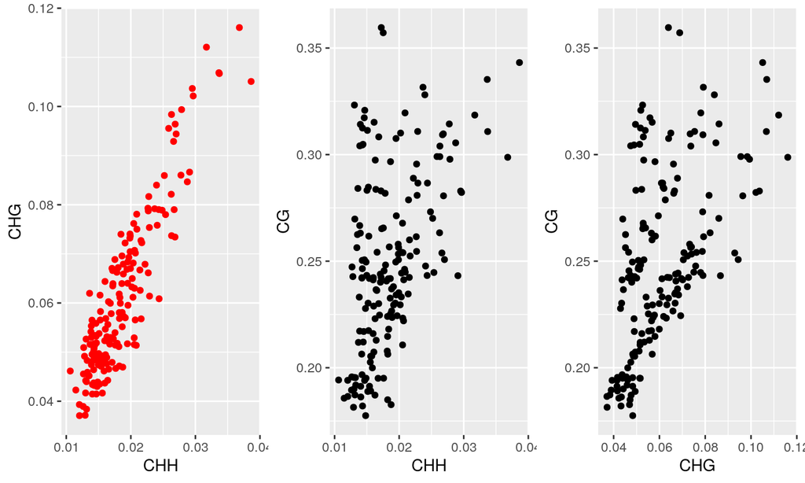

- Confounding or biology?

## Aims

- How much variation is due to
  - genetics?
  - environment?
  - their interaction?
- Is the covariance between contexts real?

## Aims

- How much variation is due to
  - genetics?
  - environment?
  - their interaction?
- Is the covariance between contexts real?
- Need to replicate individuals

## Common gardens

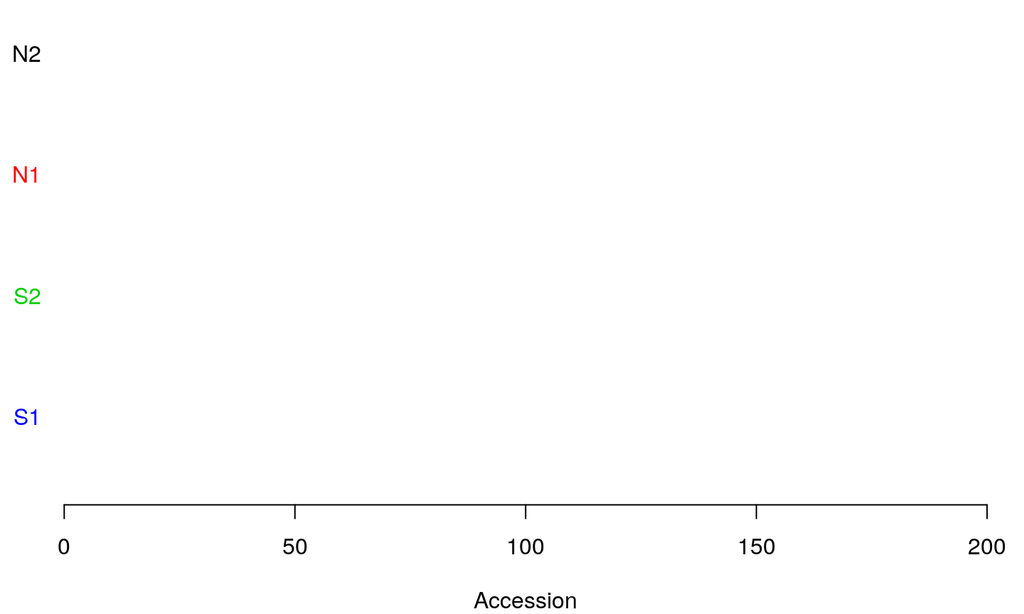

- 200 accessions at four sites in Sweden in 2011/2 by Daniele *et al.*

## Common garden design

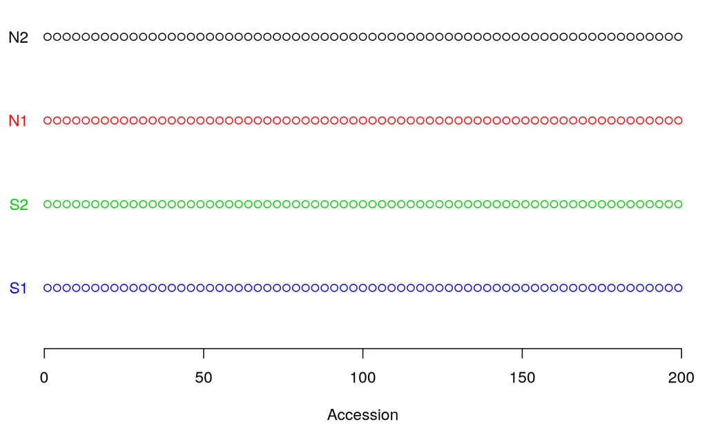

- 200 accessions at four sites in Sweden in 2011/2 by Daniele *et al.*

## Common garden design

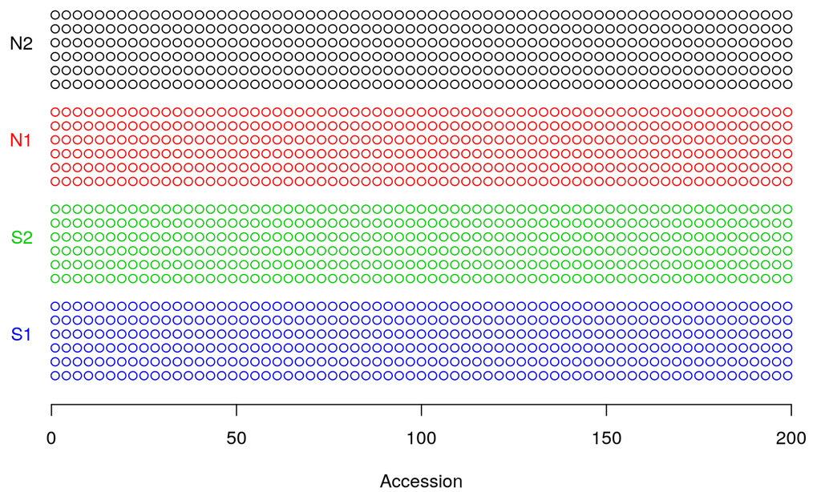

## Extensive sample

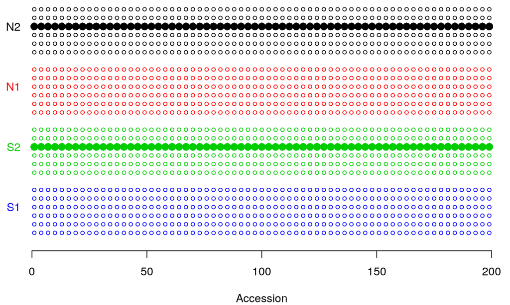

- One of each accession for mapping
- Sequencing underway for Adal and Rathke

## Intensive sample

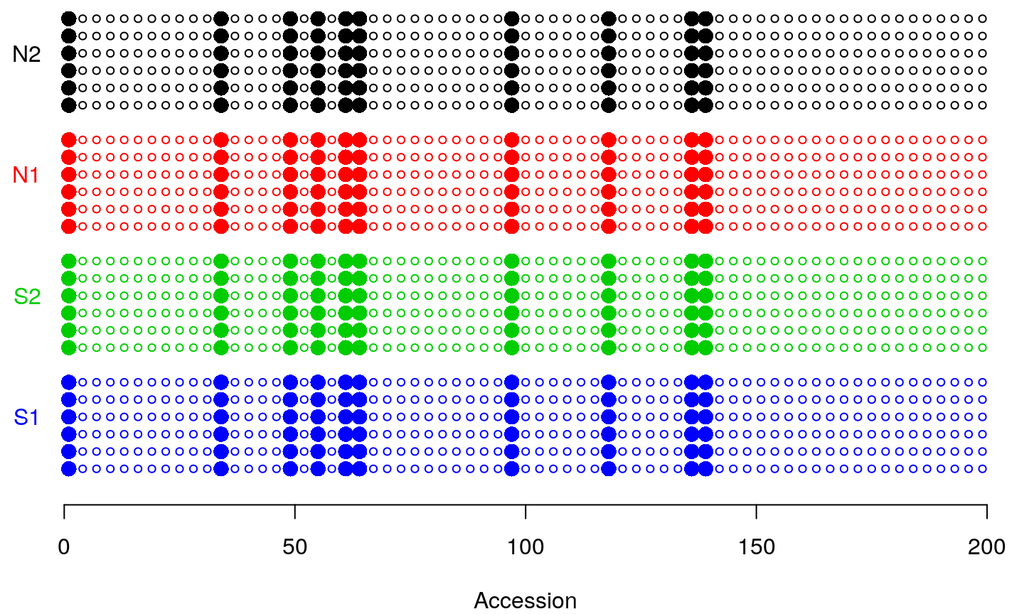

- All (=2-6) replicates of 12 accessions at each site
- Partition variance into G, E, and GxE

## Batch effects tho

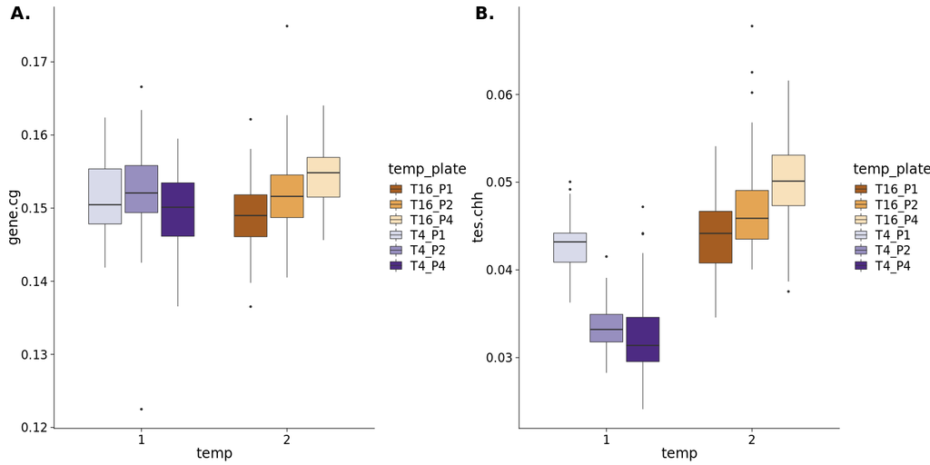

- Rahul: one plate misbehaves for CHH, but not CG
- Growth, harvest and sequencing are colinear

## Batch effects in the common-garden data

## My data

- Plates 144, 145:
  - Intensive sample
  - Replicate genotypes
  - 12 genotypes
  - 4 sites

## My data

- Plates 144, 145:
  - Intensive sample
  - Replicate genotypes
  - 12 genotypes
  - 4 sites
- Plates 167, 168, 169, (170, 171):
  - Extensive (GWAS) panel
  - 200 accessions
  - 1 replicate each
  - 2 sites

## My data

- Plates **144, 145**:
  - Intensive sample
  - Replicate genotypes
  - 12 genotypes
  - 4 sites
- Plates **167**, 168, 169, (170, 171):
  - Extensive (GWAS) panel
  - 200 accessions
  - 1 replicate each
  - 2 sites

## Plate effect: CHH-CHG covariance

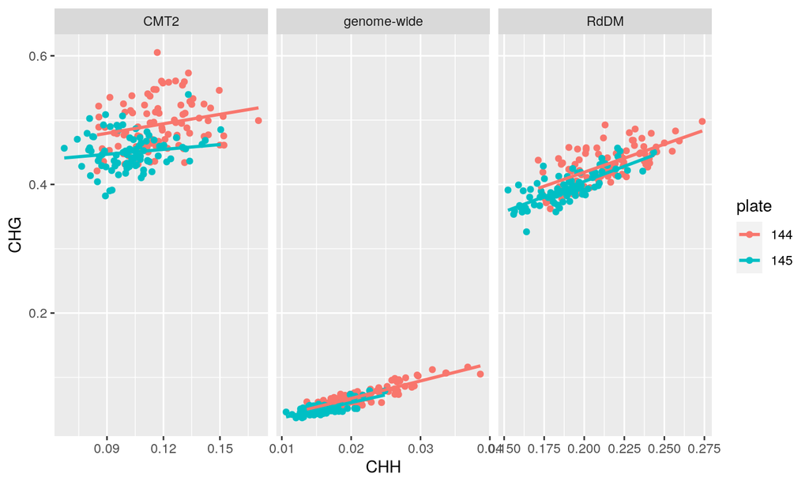

- CHG and CHH behave like phenotypes

## Plate effect even on CG

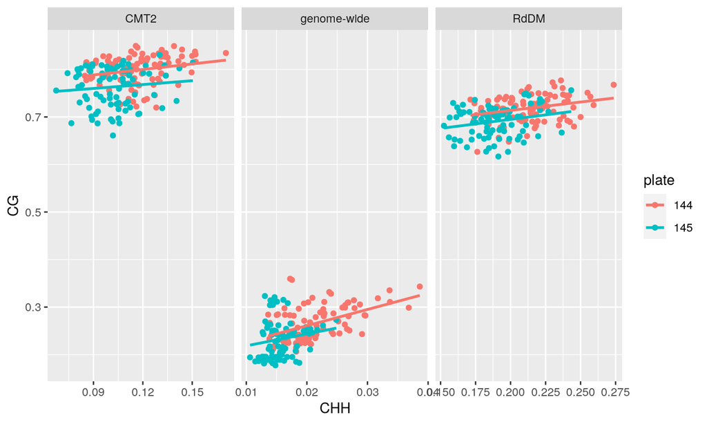

## Plates well mixed by site

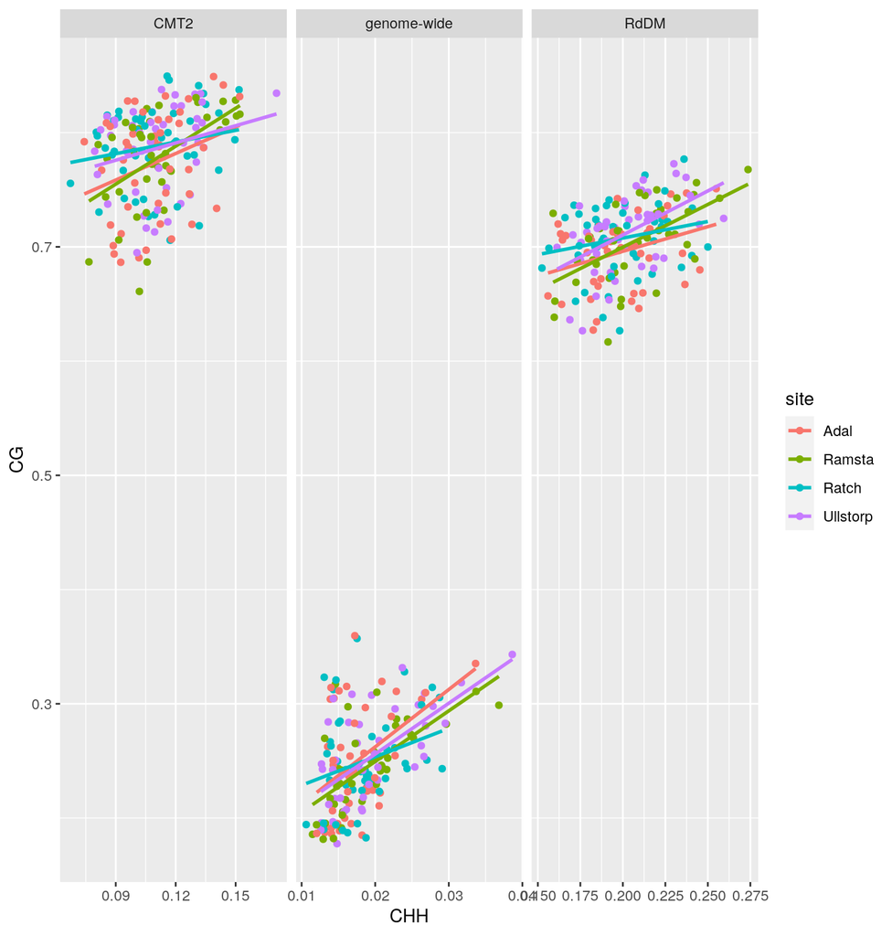

## Plates well mixed by genotype

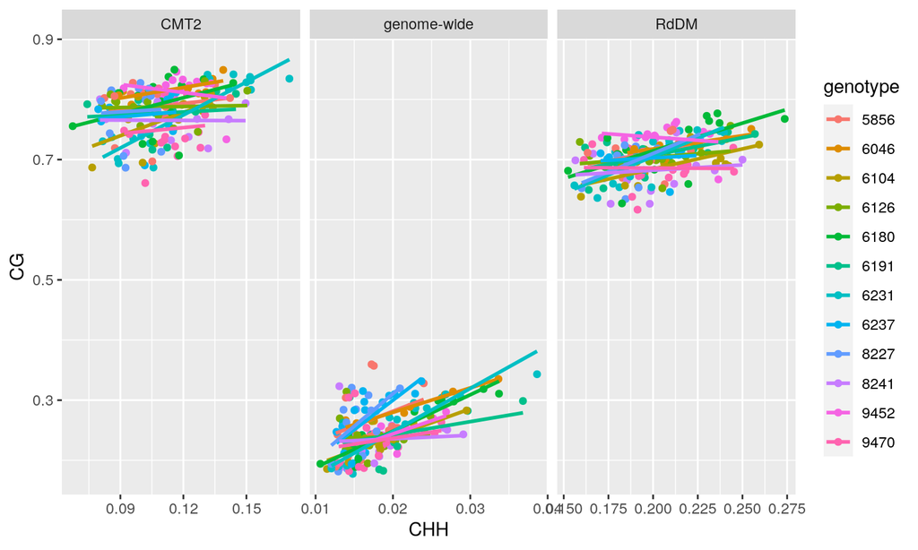

- (mostly: they are unbalanced)

## Plate explains CG

- Partition variance in CG
- Across the genome, and at CMT2- and RdDM targetted TEs

## Plate explains CG

- H<sup>2</sup> ~ 0.1
- Strong plate effect, tons of noise

## Plate explains CG

- CG should be stable!

## Plate affects everything

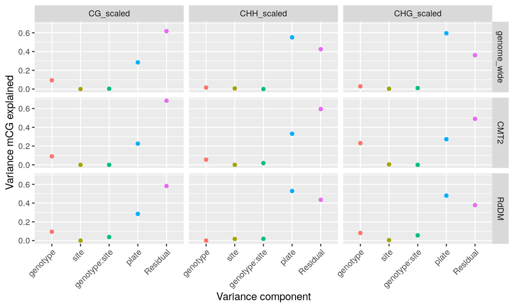

- Strong plate and residual error wherever you look

## What drives the plate effects?

## Possible sources of batch effects

1. Microenvironments in the experiment
2. Tissue sampling
3. Plate confounded with site/genotype
4. Tissue plating
5. Lab processing
6. Data processing of sequence data

## Microenvironments

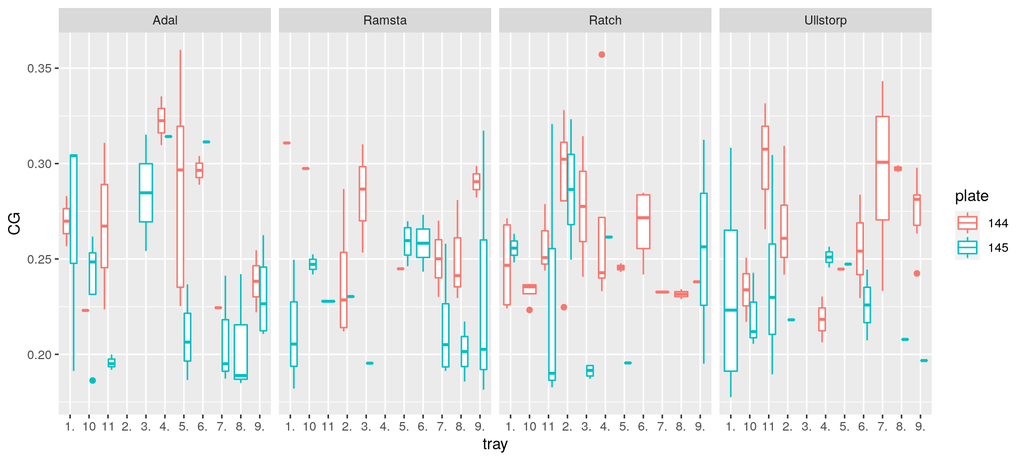

- Samples are (fairly) even across trays
- 144 > 145 *within* trays

## Tissue sampling

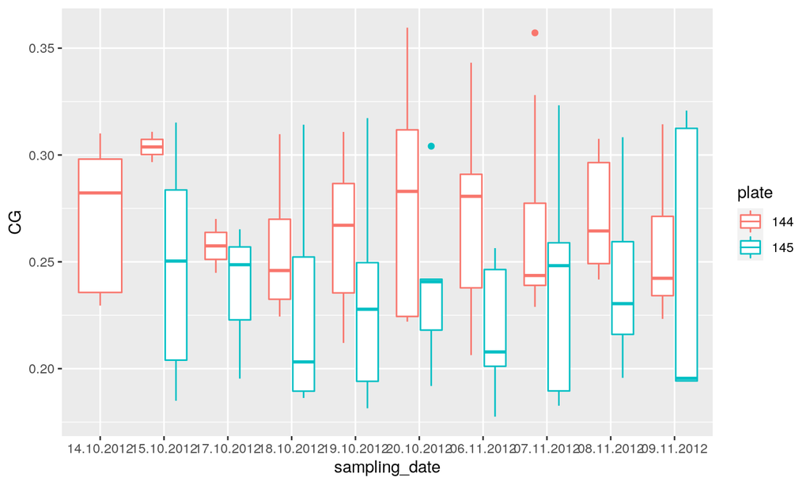

## Confounding by site/genotype

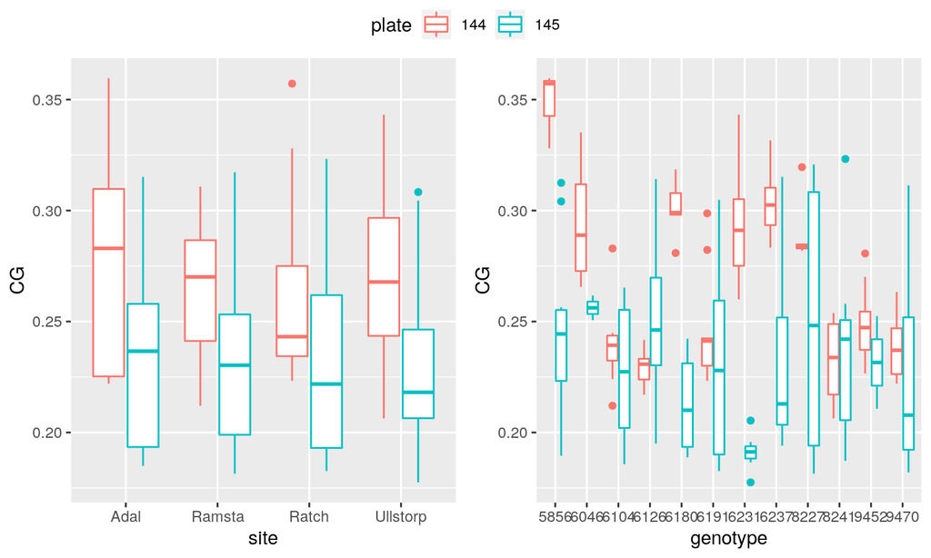

## Possible sources of batch effects

1. Microenvironments in the experiment: **No**
2. Tissue sampling: **No**
3. Plate confounded with site/genotype: **No**
4. Tissue plating
5. Lab processing
6. Data processing of sequence data

## Possible sources of batch effects

1. Microenvironments in the experiment
2. Tissue sampling
3. Plate confounded with site/genotype
4. Tissue plating
5. Lab processing
6. Data processing of sequence data
- Something happened after they came out of the freezer

## Tissue plating

- Tissue defrosts -> bad things happen

## Tissue plating

- Tissue defrosts → bad things happen
- Plate 167 by me
- Plates 144, 145 before me

## Lab processing

- Repeat sequencing of what tissue is still available
- Include technical and biological replicates

## Data processing

- Code variance: Eriko, Rahul and I wrote different scripts to:
  - Map reads to the reference genome
  - Calculate mean methylation levels
- We are checking for differences

## Mapping reads

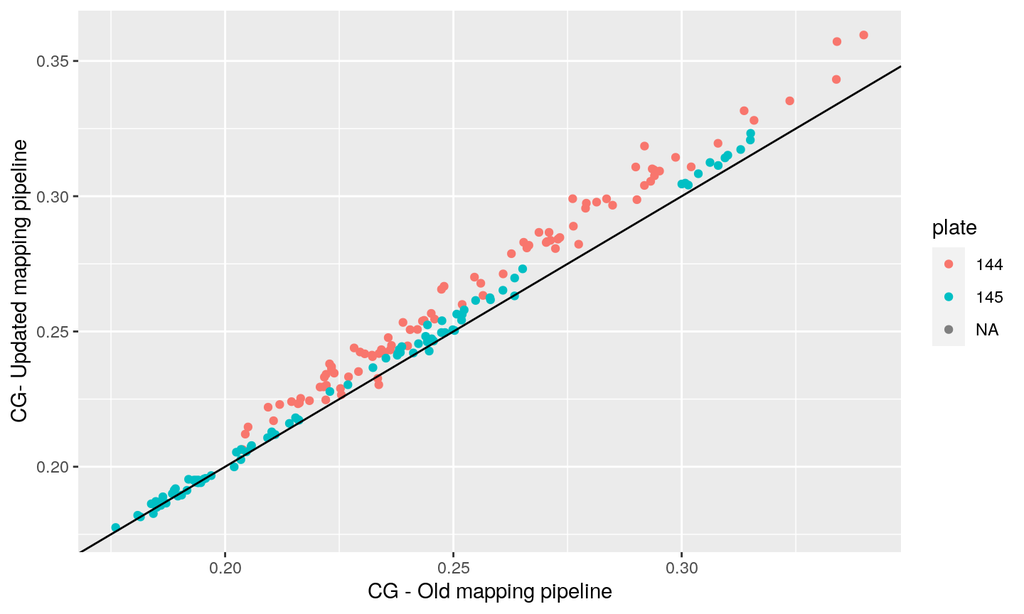

- We changed settings for mapping reads
- Correlation > 0.99

## Calculating average methylation

- Genome-wide: my script
- TEs: Eriko’s script

## Possible sources of batch effects

1. Microenvironments in the experiment
2. Tissue sampling
3. Plate confounded with site/genotype
4. Tissue plating
5. Lab processing
6. Data processing of sequence data
- Something happened after they came out of the freezer

## Conclusion

- Differences between plates are substantial
- We don’t really know why though
- Need to include techincal/biological replication

## Conclusion

- Differences between plates are substantial
- We don’t really know why though
- Need to include technical/biological replication
- Good chance these data are garbage